# HW1 George W Nakhla

Package installs:

```r
#install.packages("MPV")
library("MPV")
library("knitr")
```

## Q1: Question 2.3. Table B.2 presents data collected during a solar energy project at Georgia Tech

### a) Fit a simple linear regression model relating total heat flux y (kilowatts) to the radial deflection of the deflected rays x4 (milliradians).

```r
solarData <- table.b2
fit <- lm( y ~ x4, data = solarData)
lm( y ~ x4, data = solarData)
```

```
##
## Call:
## lm(formula = y ~ x4, data = solarData)
##
## Coefficients:
## (Intercept)           x4
##       607.1        -21.4
```

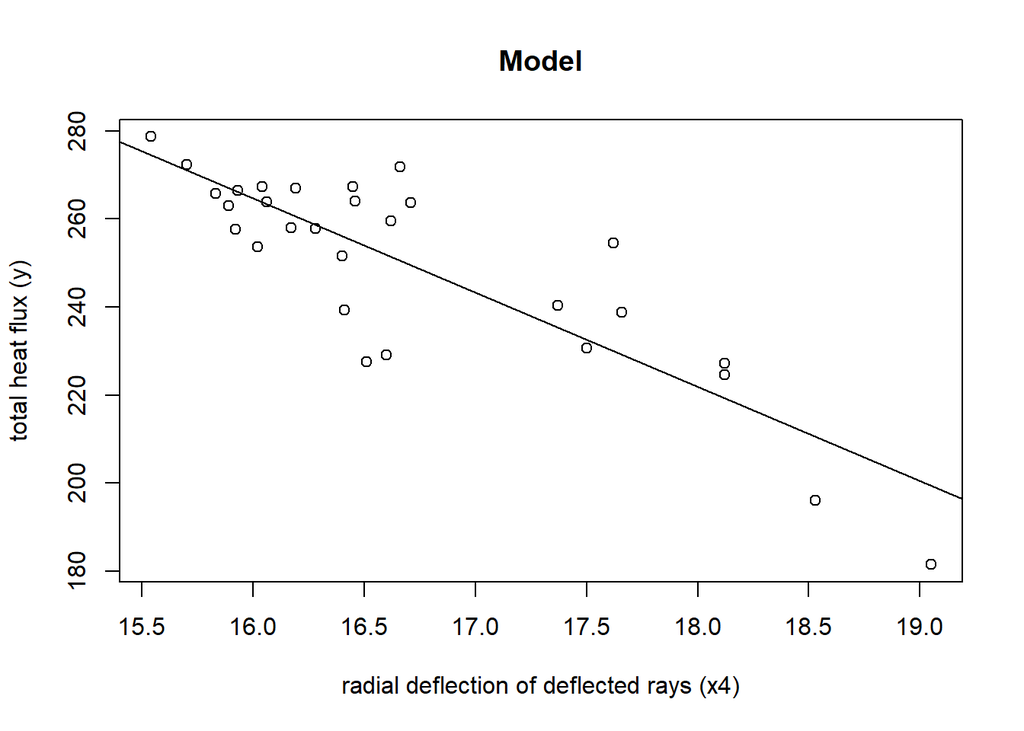

```r
plot(solarData$x4, solarData$y,
     xlab = "radial deflection of deflected rays (x4)",
     ylab = "total heat flux (y)",
     main = "Model")
abline(fit)
```

So we have the equation y = 607.1 -21.4(x4) as plotted above. This is a negative relationship, and describes that for each one unit increase in x4, we can expect a 21.4 unit decrease of y. The 607.1 can be interpreted as a radial deflection of 0, we can expect a heat flux to be 607.1

### b) Construct the analysis-of-variance table and test for significance of regression.

```r
# here, we want to conduct a hypothesis test for our regression coefficient. Our H0 (null hypothesis) is that there is no relationship between x4 and y (B1 is 0). The alternative hypothesis is that B1 is non 0. In this case, the previous graph more strongly suggests that B1 is less than 0, or an inverse relationship.
summary(fit)
```

```
##
## Call:
## lm(formula = y ~ x4, data = solarData)
##
## Residuals:
##      Min       1Q   Median       3Q      Max
## -26.2487  -4.5029   0.5202   7.9093  24.5080
##
## Coefficients:
##             Estimate Std. Error t value Pr(>|t|)
## (Intercept)  607.103     42.906  14.150 5.24e-14 ***
## x4           -21.402      2.565  -8.343 5.94e-09 ***
## ---
## Signif. codes:  0 '***' 0.001 '**' 0.01 '*' 0.05 '.' 0.1 ' ' 1
##
## Residual standard error: 12.33 on 27 degrees of freedom
## Multiple R-squared:  0.7205, Adjusted R-squared:  0.7102
## F-statistic: 69.61 on 1 and 27 DF,  p-value: 5.935e-09
```

```r
anova(fit)
```

```
## Analysis of Variance Table
##
## Response: y
##           Df  Sum Sq Mean Sq F value    Pr(>F)
## x4         1 10578.7   10579  69.609 5.935e-09 ***
## Residuals 27  4103.2     152
## ---
## Signif. codes:  0 '***' 0.001 '**' 0.01 '*' 0.05 '.' 0.1 ' ' 1
```

72.05% of the variance in y is explained by x4  
The p value of the F statistic is extremely low (5.935e-09), indicating that the overall model is significant and that the slope (B1) is not zero. We reject the initial hypothesis in favor of the alternative.

### c) Find a 99% CI on the slope.

```r
conf_interval <- confint(fit, level = 0.99)
print(conf_interval)
```

```
##                 0.5 %    99.5 %
## (Intercept) 488.22411 725.98242
## x4          -28.50995 -14.29497
```

After running this and seeing the results, we can say that we are 99% certain that the true slope of the regression (beta1) falls between:  
(-28.50995, -14.29497)

### d) Calculate R<sup>2</sup>

```r
#previously printed the summary, but this will show only r^2
summary(fit)$r.squared
```

```
## [1] 0.7205242
```

Again, we can say that 72.05% of the variance in y is explained by x4 based on this r^2 value

### e) Find a 95% CI on the mean heat flux when the radial deflection is 16.5 milliradians.

```r
# Define the new data point
new_data <- data.frame(x4 = 16.5)

# Predict the mean heat flux and obtain confidence intervals
prediction <- predict(fit, newdata = new_data, interval = "confidence", level = 0.95)

# Print the prediction and confidence intervals
print(prediction)
```

```
##        fit      lwr      upr
## 1 253.9627 249.1468 258.7787
```

We see that based on the model, we get an expected heat flux of 253.9627 kilowatts. We are 95% certain that the true expected heat flux would be between:  
(249.1468, 258.7787)

### a) Fit a simple linear regression model relating selling price of the house to the current taxes ( x1 ).

```r
houseData <- table.b4
lm(y ~ x1, data = houseData)
```

```
##
## Call:
## lm(formula = y ~ x1, data = houseData)
##
## Coefficients:
## (Intercept)           x1
##      13.320        3.324
```

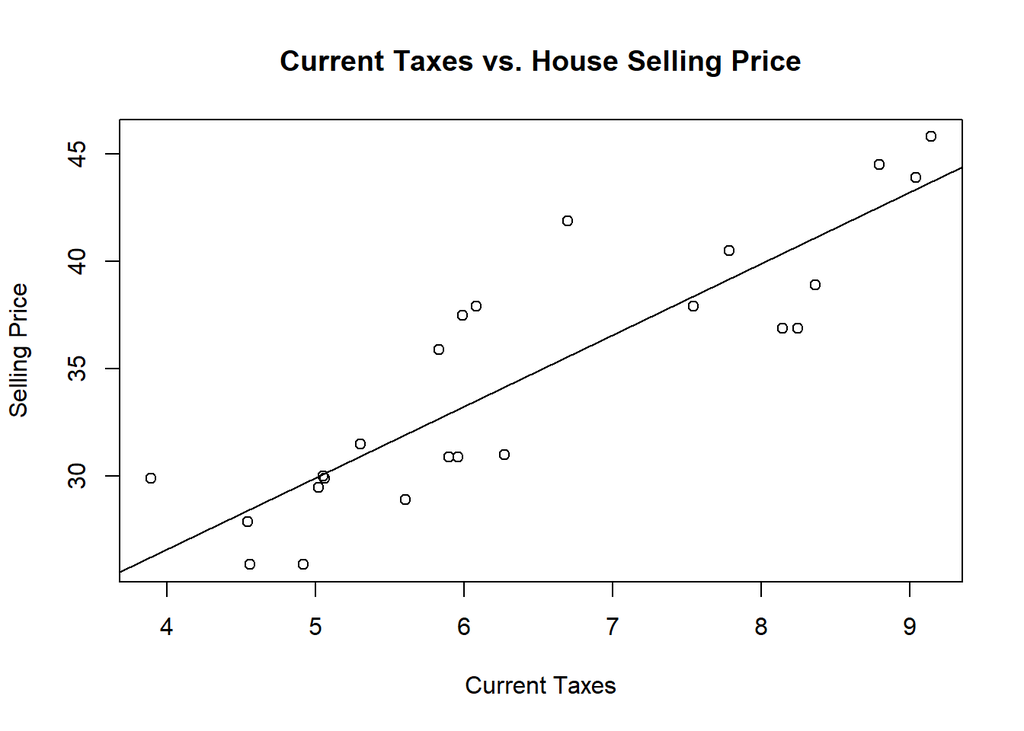

```r
homeFit <- lm(y ~ x1, data = houseData)
plot(houseData$x1,houseData$y,
     xlab = "Current Taxes",
     ylab = "Selling Price",
     main = "Current Taxes vs. House Selling Price")
abline(homeFit)
```

Based on the regression, we see that the equation of the model plotted above is: y = 13.320 + 3.324(x1). This suggests that for each 1 unit increase in x1, we can expect a 3.324 increase in y. The interpretation of 13.320 is that at a tax cost of 0 (which in this case is unrealistic), we can expect a house selling price of 13.320.

### b) Test for significance of regression.

```r
# here, we want to conduct a hypothesis test for our regression coefficient. Our H0 (null hypothesis) is that there is no relationship between x1 and y (B1 is 0). The alternative hypothesis is that B1 is non 0. In this case, the previous graph more strongly suggests that B1 is greater than 0, or a positive relationship.
summary(homeFit)
```

```
##
## Call:
## lm(formula = y ~ x1, data = houseData)
##
## Residuals:
##     Min      1Q  Median      3Q     Max
## -3.8343 -2.3157 -0.3669  1.9787  6.3168
##
## Coefficients:
##             Estimate Std. Error t value Pr(>|t|)
## (Intercept)  13.3202     2.5717   5.179 3.42e-05 ***
## x1            3.3244     0.3903   8.518 2.05e-08 ***
## ---
## Signif. codes:  0 '***' 0.001 '**' 0.01 '*' 0.05 '.' 0.1 ' ' 1
##
## Residual standard error: 2.961 on 22 degrees of freedom
## Multiple R-squared:  0.7673, Adjusted R-squared:  0.7568
## F-statistic: 72.56 on 1 and 22 DF,  p-value: 2.051e-08
```

At a p-value of 2.051e-08, we can confidently reject the null hypothesis in favor of the alternate. This is evidence that there is a non-zero relationship between tax cost and house selling price.

### c) Calculate R<sup>2</sup>

```r
summary(homeFit)$r.squared
```

```
## [1] 0.7673344
```

### d) Find a 95% CI on the slope.

```r
confint(homeFit, level = 0.95)
```

```
##                2.5 %    97.5 %
## (Intercept) 7.986755 18.653604
## x1          2.514988  4.133754
```

We are 95% certain that the true slope of B1 lies between: (2.514988, 4.133754)

### e) Find a 95% CI on the mean selling price of a house for which the current taxes are $750.

```r
# NOTE: x1 is documented to be represented in thousands, so we will use 750/1000 = .75
new_data <- data.frame(x1 = .75)
predict(homeFit, newdata = new_data, interval = "confidence", level = 0.95)
```

```
##        fit      lwr      upr
## 1 15.81346 11.06792 20.55899
```

NOTE: All in thousands The prediction model expresses that we can expect a house selling price of 15.81346 for a tax cost of .75. We are 95% certain that the true selling price for a house with a .75 tax cost is:  
(11.06792, 20.55899)

## Q3: Question 2.7. The purity of oxygen produced by a fractional distillation process is thought to be related to the percentage of hydrocarbons in the main condenser of the processing unit.

### a) Fit a simple linear regression model to the data.

```r
chemData <- p2.7
chemFit = lm(purity ~ hydro, data = chemData)
print(chemFit)
```

```
##
## Call:
## lm(formula = purity ~ hydro, data = chemData)
##
## Coefficients:
## (Intercept)        hydro
##       77.86        11.80
```

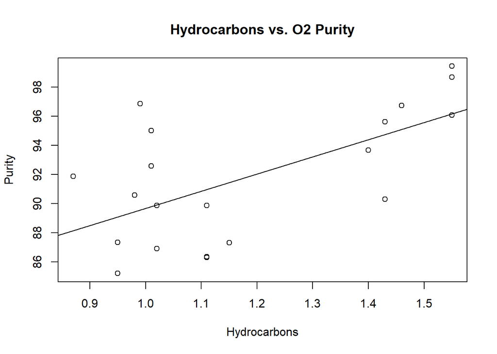

```r
plot(chemData$hydro, chemData$purity,
     xlab = "Hydrocarbons",
     ylab = "Purity",
     main = "Hydrocarbons vs. O2 Purity")
abline(chemFit)
```

The formula describing the model is y = 77.86 + 11.80β1, where 77.86 represents the oxygen purity at a 0 percent hydrocarbon concentration and 11.80 represents the expected units of increase of y for every unit of x.

### b) Test the hypothesis H0:β1 = 0.

```r
# we can set up our null hypothesis to be: H0:β1 = 0
# Our alternative hypothesis, H_a is β1 != 0
# since no alpha value is given, we can assume to have a two tailed test with an alpha of .1
# we can conduct this with a hypothesis t test. we can find the p value by calling:
summary(chemFit)
```

```
##
## Call:
## lm(formula = purity ~ hydro, data = chemData)
##
## Residuals:
##     Min      1Q  Median      3Q     Max
## -4.6724 -3.2113 -0.0626  2.5783  7.3037
##
## Coefficients:
##             Estimate Std. Error t value Pr(>|t|)
## (Intercept)   77.863      4.199  18.544 3.54e-13 ***
## hydro         11.801      3.485   3.386  0.00329 **
## ---
## Signif. codes:  0 '***' 0.001 '**' 0.01 '*' 0.05 '.' 0.1 ' ' 1
##
## Residual standard error: 3.597 on 18 degrees of freedom
## Multiple R-squared:  0.3891, Adjusted R-squared:  0.3552
## F-statistic: 11.47 on 1 and 18 DF,  p-value: 0.003291
```

### c) c. Calculate R<sup>2</sup>

```r
summary(chemFit)$r.squared
```

```
## [1] 0.3891224
```

We get an R<sup>2</sup> value of 0.3891224. This means that 38.91224% of the variability in the oxygen purity can be attributed to the percentage of hydrocarbons in the main condenser.

### d) Find a 95% CI on the slope.

```r
confint(chemFit, level = 0.95)
```

```
##                 2.5 %   97.5 %
## (Intercept) 69.041747 86.68482
## hydro        4.479066 19.12299
```

We are 95% certain that the true slope (β1) falls between: (4.479066, 19.12299)

### e) Find a 95% CI on the mean purity when the hydrocarbon percentage is 1.00.

```r
new_data = data.frame(hydro = 1.00)
predict(chemFit, newdata = new_data, interval = "confidence", level = 0.95)
```

```
##        fit      lwr      upr
## 1 89.66431 87.51017 91.81845
```

The model predicts that at a hydrocarbon percentage of 1.00, the purity will be at 89.66%. We are 95% certain that the true purity will be between (in percent): (87.51017, 91.81845)

## Q4: Question 2.8. Consider the oxygen plant data in Problem 2.7 and assume that purity and hydrocarbon percentage are jointly normally distributed random variables.

### a) What is the correlation between oxygen purity and hydrocarbon percentage?

```r
# we are using the same data as Q3

# two ways to calculate it!
cor(chemData$purity, chemData$hydro)
```

```
## [1] 0.6237968
```

```r
sqrt(summary(chemFit)$r.squared)
```

```
## [1] 0.6237968
```

The correlation coefficient (r) is equal to 0.6237968. This indicates a moderately strong positive linear relationship between the hydrocarbon % and the purity of the oxygen.

### b) Test the hypothesis that ρ = 0.

```r
# can assume alpha of .1
# H0 :ρ = 0; our alternate hypothesis is that ρ != 0. We can conduct Pearson's product moment correlation by calling:
cor.test(chemData$purity, chemData$hydro)
```

```
##
##  Pearson's product-moment correlation
##
## data:  chemData$purity and chemData$hydro
## t = 3.3861, df = 18, p-value = 0.003291
## alternative hypothesis: true correlation is not equal to 0
## 95 percent confidence interval:
##  0.2503961 0.8356439
## sample estimates:
##       cor
## 0.6237968
```

```r
# and checking the p-value
```

We get a p value of .003 which is less than our alpha, and as such gives us sufficient evidence to reject H0 in favor of our alternate.

### c) Construct a 95% CI for ρ.

```r
# can call the same function as before as it also gives us a 95% CI
cor.test(chemData$purity, chemData$hydro)
```

```
##
##  Pearson's product-moment correlation
##
## data:  chemData$purity and chemData$hydro
## t = 3.3861, df = 18, p-value = 0.003291
## alternative hypothesis: true correlation is not equal to 0
## 95 percent confidence interval:
##  0.2503961 0.8356439
## sample estimates:
##       cor
## 0.6237968
```

We see that running this gives us a 95% CI of (0.2503961, 0.8356439). The interpretation of this is that we are 95% certain that the true value of ρ lies between:  
(0.2503961, 0.8356439)